# Cancer Rate in the Borders

S. M. Cusick

# 1 Introduction

The following presentation explores the **incidence of cancer** within the **NHS Borders** health board.

This presentation was prepared to **inform** NHS Borders on their **historic provision of cancer treatment services**, in order to create a foundation to be used in further studies and future recommendations into increasing the efficiency of cancer treatment services.

# 2 Visualisations

## 2.1 Most Common Cancers

The following bar graph looks at the most common cancer types, separated by sex, within NHS Borders as well as how they compare to the most common cancer types throughout Scotland.

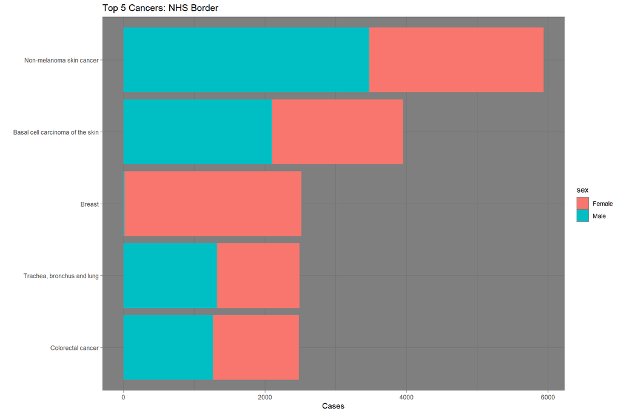

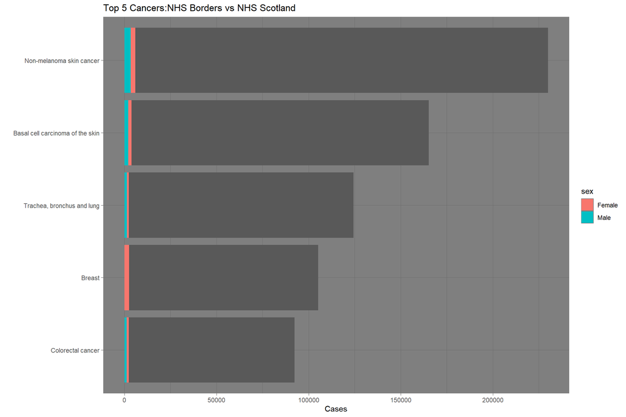

## 2.2 Borders from 1995

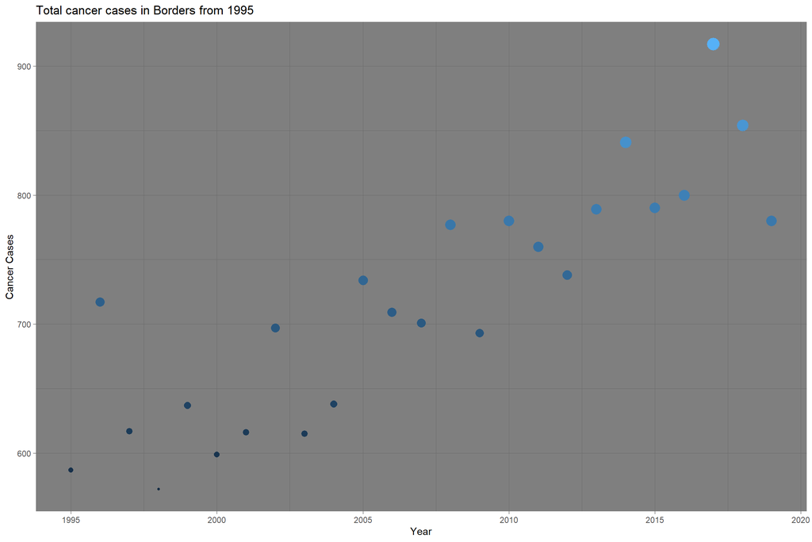

Historically, there has been a higher percentage of female to male cancer patients, although this gap has closed or went over in the past few years.

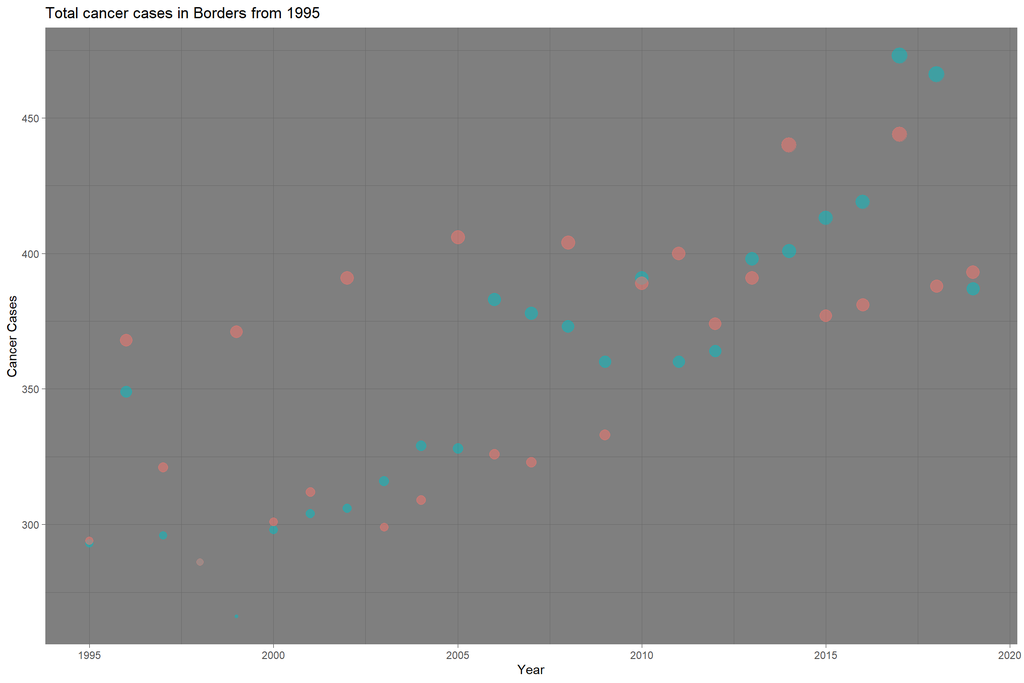

## 2.3 Borders in 2019

The graph below show the distribution of cancer incidences, with male in Yellow and female in Black. Most notable is the large amount, and large difference between sexes for **non-melona skin cancer**.

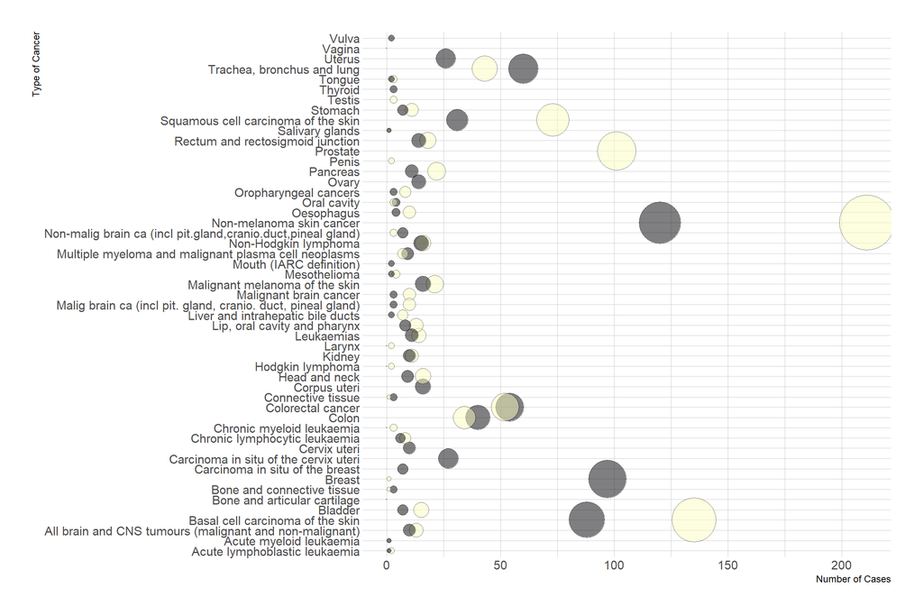